# PHÂN TÍCH ĐỊNH TÍNH BẰNG AI & PhoBERT

## Bổ sung và kiểm chứng cho mã hóa thủ công MaxQDA — nghiên cứu Văn hóa chất lượng trường phổ thông liên cấp

**Nghiên cứu sinh:** Đặng Thị Kim Sơn — Khoa Quản lí Giáo dục, Trường ĐHSP TP.HCM

### Mục đích

Notebook này **không thay thế** mã hóa thủ công MaxQDA mà bổ sung ba giá trị:

1. **Kiểm chứng độ tin cậy** — cấu trúc chủ đề do AI phát hiện có trùng với hệ mã do con người xây dựng không?
2. **Phát hiện mẫu hình quy mô lớn** — điều mà đọc thủ công 6.280 đoạn trích khó thấy: mạng lưới đồng xuất hiện mã, khác biệt diễn ngôn giữa nhóm, cấu trúc ngữ nghĩa tiềm ẩn.
3. **Lượng hóa định tính** — chuyển dữ liệu định tính thành ma trận số để tích hợp với định lượng (mixed methods).

### Nguyên tắc phương pháp

- AI được dùng như **"người mã hóa thứ hai"**, không phải người mã hóa duy nhất. Mọi kết quả AI đều được đối chiếu với mã MaxQDA.
- **Không tạo dữ liệu mới.** Toàn bộ đầu vào là các đoạn trích đã mã hóa trong workbook MaxQDA.
- Mọi chỉ số đồng thuận (ARI, NMI, kappa) được báo cáo trung thực, kể cả khi thấp.

### Yêu cầu cài đặt

```
pip install torch transformers sentence-transformers bertopic hdbscan umap-learn
pip install underthesea pyvi networkx scikit-learn pandas openpyxl matplotlib seaborn
```

Nếu máy có GPU, PhoBERT sẽ chạy nhanh hơn nhiều. Không có GPU vẫn chạy được (chậm hơn ~5-10 lần).

### Cấu trúc notebook

| Phần | Nội dung |
| --- | --- |
| 1-2 | Trích xuất & làm sạch dữ liệu từ MaxQDA |
| 3 | Nhúng ngữ nghĩa bằng PhoBERT |
| 4 | Phân cụm ngữ nghĩa & đối chiếu với mã người (ARI/NMI/purity) |
| 5 | Mô hình chủ đề BERTopic |
| 6 | Phân tích cảm xúc (sentiment) theo mã và theo nhóm |
| 7 | Mạng lưới đồng xuất hiện mã & đo độ trung tâm |
| 8 | Hội tụ - phân kỳ liên trường (lượng hóa) |
| 9 | So sánh diễn ngôn GV Việt vs GV nước ngoài |
| 10 | Kiểm định độ tin cậy AI - người (Cohen's kappa) |
| 11 | Xuất ma trận định lượng hóa cho phân tích hỗn hợp |

```python
from google.colab import drive
import os

# Attempt to unmount first if it's already mounted
if os.path.exists('/content/drive'):
    try:
        drive.flush_and_unmount()
        print('Google Drive unmounted.')
    except ValueError:
        pass # Drive might not have been mounted initially

# Ensure the mount point is empty
if os.path.exists('/content/drive'):
    # Only remove content if it's a directory, avoid removing the mount point itself if it's a special file
    if os.path.isdir('/content/drive') and os.listdir('/content/drive'):
        print('Clearing existing content in /content/drive...')
        !rm -rf /content/drive/*

# Mount Google Drive with force_remount=True
drive.mount('/content/drive', force_remount=True)
```

```python
!pip install torch transformers sentence-transformers bertopic hdbscan umap-learn
!pip install underthesea pyvi networkx scikit-learn pandas openpyxl matplotlib seaborn
```

[output not shown]

```python
# 1. Thư viện & cấu hình
import warnings; warnings.filterwarnings('ignore')
import os, re, json, glob, unicodedata
import numpy as np, pandas as pd
import matplotlib.pyplot as plt, seaborn as sns

pd.set_option('display.max_colwidth', 120)
plt.rcParams['figure.dpi'] = 110

# === CHỈNH ĐƯỜNG DẪN NÀY CHO MÁY CỦA BẠN ===
DINHTINH = '/content/drive/MyDrive/HuongDanSV/MsSonTDTU/DinhTinh'
OUT = os.path.join(DINHTINH, 'Phan_Tich_AI', 'ket_qua_ai')
os.makedirs(OUT, exist_ok=True)

# PhoBERT model (v2 tốt hơn cho văn nói)
PHOBERT_MODEL = 'vinai/phobert-base-v2'
SENTIMENT_MODEL = 'wonrax/phobert-base-vietnamese-sentiment'  # thay bằng model khác nếu cần

RANDOM_STATE = 42
np.random.seed(RANDOM_STATE)
print('Thư mục dữ liệu:', DINHTINH)
print('Thư mục kết quả :', OUT)
```

```
Thư mục dữ liệu: /content/drive/MyDrive/HuongDanSV/MsSonTDTU/DinhTinh
Thư mục kết quả : /content/drive/MyDrive/HuongDanSV/MsSonTDTU/DinhTinh/Phan_Tich_AI/ket_qua_ai
```

## 2. Trích xuất dữ liệu từ workbook MaxQDA

Workbook có cấu trúc ma trận: **hàng = mã (code)**, **cột = nguồn (người được phỏng vấn)**, **ô = đoạn trích nguyên văn**. Ta chuyển về dạng tidy: mỗi dòng là một *đoạn trích được mã hóa* (coded segment).

```python
# 2.1 Hàm trích xuất
def extract_workbook(path, role_label):
    """Trích xuất các đoạn đã mã hóa từ một workbook MaxQDA dạng ma trận."""
    xl = pd.ExcelFile(path)
    rows = []
    for sheet in xl.sheet_names:
        d = xl.parse(sheet, header=None)
        if d.shape[0] < 3 or d.shape[1] < 2:
            continue
        # cột nguồn: header ở hàng 0, bỏ các cột 'Tóm tắt'
        src_cols = {}
        for j in range(1, d.shape[1]):
            h = d.iloc[0, j]
            if isinstance(h, str) and h.strip() and not h.strip().startswith('Tóm'):
                src_cols[j] = h.strip().replace('\n', ' ')
        for i in range(2, d.shape[0]):
            code = d.iloc[i, 0]
            if not isinstance(code, str) or not code.strip():
                continue
            code = code.strip()
            for j, src in src_cols.items():
                cell = d.iloc[i, j]
                if isinstance(cell, str) and len(cell.strip()) > 25:
                    rows.append({'role': role_label, 'sheet': sheet, 'code': code,
                                 'source': src, 'raw': cell.strip()})
    return pd.DataFrame(rows)

# Các cột KHÔNG phải người trả lời mà là phần tổng hợp do NCS tự viết.
# Dữ liệu này rất quý (đã có sẵn phán đoán hội tụ/phân kì) nhưng PHẢI tách riêng,
# tuyệt đối không trộn với trích dẫn phỏng vấn khi phân tích diễn ngôn.
ANALYST_KEYS = ['hội tụ', 'phân kì', 'phân kỳ', 'diễn giải', 'mức độ bằng chứng',
                'loại quan hệ', 'nhận định', 'tóm tắt']

def classify_source(src):
    sl = str(src).strip().lower()
    if any(k in sl for k in ANALYST_KEYS):
        return 'analyst'
    return 'informant' if re.match(r'^tr[a-e]', sl) else 'other'

FILES = [
    ('GV_5_Truong_SUM_00-10_Phan_tich_Hoi_tu_Phan_ki.xlsm', 'Giáo viên'),
    ('CBQL_5_Truong_SUM_00-10_Phan_tich_Hoi_tu_Phan_ki(1).xlsm', 'CBQL'),
]
parts = []
for fn, role in FILES:
    p = os.path.join(DINHTINH, fn)
    if os.path.exists(p):
        dfx = extract_workbook(p, role)
        print(f'{role}: {len(dfx)} đoạn từ {dfx.code.nunique()} mã, {dfx.source.nunique()} nguồn')
        parts.append(dfx)
    else:
        print('KHÔNG TÌM THẤY:', p)
seg_all = pd.concat(parts, ignore_index=True)
seg_all['seg_type'] = seg_all['source'].apply(classify_source)
print('\nTỔNG:', len(seg_all), 'ô có nội dung')
print(seg_all.seg_type.value_counts())
print('\n>>> HAI LỚP DỮ LIỆU ĐƯỢC TÁCH RIÊNG:')
print('   informant = trích dẫn nguyên văn người được phỏng vấn -> phân tích AI/diễn ngôn')
print('   analyst   = tổng hợp hội tụ/phân kì/diễn giải do NCS viết -> đối chiếu ở phần 8')
seg_all.head(3)
```

```
Giáo viên: 2813 đoạn từ 397 mã, 15 nguồn
CBQL: 3466 đoạn từ 397 mã, 21 nguồn

TỔNG: 6279 ô có nội dung
seg_type
analyst      3585
informant    2694
Name: count, dtype: int64

>>> HAI LỚP DỮ LIỆU ĐƯỢC TÁCH RIÊNG:
   informant = trích dẫn nguyên văn người được phỏng vấn -> phân tích AI/diễn ngôn
   analyst   = tổng hợp hội tụ/phân kì/diễn giải do NCS viết -> đối chiếu ở phần 8
```

|  | role | sheet | code | source | raw | seg_type |
| --- | --- | --- | --- | --- | --- | --- |
| 0 | Giáo viên | 00_CONTEXT | CTX-PARTICIPANT | Điểm hội tụ liên trường | Không áp dụng ở cấp mã nhánh. | analyst |
| 1 | Giáo viên | 00_CONTEXT | CTX-PARTICIPANT | Điểm phân kì liên trường | Không áp dụng ở cấp mã nhánh. | analyst |
| 2 | Giáo viên | 00_CONTEXT | CTX-PARTICIPANT | Phân kì nội trường | Không áp dụng ở cấp mã nhánh. | analyst |

```python
# 2.2 Làm sạch văn bản + trích metadata (trường, cấp học, quốc tịch)
def clean_text(t):
    t = unicodedata.normalize('NFC', str(t))
    t = re.sub(r'^\[[^\]]+\]:\s*', '', t)            # bỏ tiền tố [Mã_nguồn]:
    t = re.sub(r'\[[A-Z0-9\-_>]+\]', ' ', t)          # bỏ nhãn mã trong ngoặc vuông
    t = re.sub(r'\b[A-Za-z]+\\\S+', ' ', t)            # bỏ đường dẫn file MaxQDA
    t = re.sub(r'Transcript:\s*\d+\s*-\s*\d+\s*\(\d+\)', ' ', t)
    t = re.sub(r'\s+', ' ', t)
    return t.strip()

FILLERS = ['dạ', 'vâng', 'ừ', 'ờ', 'à', 'ạ', 'nha', 'nhé', 'thì', 'là', 'mà']
def strip_fillers(t):
    words = t.split()
    out = [w for w in words if w.lower().strip('.,') not in FILLERS]
    return ' '.join(out)

# Tách hai lớp
seg = seg_all[seg_all.seg_type == 'informant'].copy().reset_index(drop=True)
analyst = seg_all[seg_all.seg_type == 'analyst'].copy().reset_index(drop=True)
print(f'Trích dẫn phỏng vấn : {len(seg)}')
print(f'Tổng hợp của NCS    : {len(analyst)}')

seg['text'] = seg['raw'].apply(clean_text)
seg['text_nofill'] = seg['text'].apply(strip_fillers)
seg['n_words'] = seg['text'].str.split().str.len()

# Metadata từ mã nguồn: TrA_GVTHCS, TrB_GVTHCS_THPT3_NN, ...
seg['school'] = seg['source'].str.extract(r'^(Tr[A-E])', expand=False)
seg['is_foreign'] = seg['source'].str.contains('_NN', na=False)
seg['level'] = np.select(
    [seg['source'].str.contains('THPT'), seg['source'].str.contains('THCS'), seg['source'].str.contains('TH')],
    ['THPT', 'THCS', 'Tiểu học'], default='Khác')
seg['theme_block'] = seg['sheet'].str.extract(r'^(\d+)', expand=False)

# Lọc đoạn quá ngắn (nhiễu)
seg = seg[seg['n_words'] >= 5].reset_index(drop=True)
print('Sau lọc:', len(seg), 'đoạn |', seg.code.nunique(), 'mã |', seg.source.nunique(), 'nguồn')
print('\nPhân bố theo trường:'); print(seg.school.value_counts(dropna=False))
print('\nNguồn nước ngoài:', seg[seg.is_foreign].source.nunique(), 'người,', int(seg.is_foreign.sum()), 'đoạn')
analyst['text'] = analyst['raw'].apply(clean_text)
seg.to_csv(f'{OUT}/00_segments_tidy.csv', index=False, encoding='utf-8-sig')
analyst.to_csv(f'{OUT}/00b_analyst_synthesis.csv', index=False, encoding='utf-8-sig')
seg[['role','sheet','code','source','school','is_foreign','n_words','text']].head(5)
```

```
Trích dẫn phỏng vấn : 2694
Tổng hợp của NCS    : 3585
Sau lọc: 2694 đoạn | 338 mã | 24 nguồn

Phân bố theo trường:
school
TrB    1318
TrA     566
TrE     377
TrD     218
TrC     215
Name: count, dtype: int64

Nguồn nước ngoài: 3 người, 328 đoạn
```

|  | role | sheet | code | source | school | is_foreign | n_words | text |
| --- | --- | --- | --- | --- | --- | --- | --- | --- |
| 0 | Giáo viên | 00_CONTEXT | CTX-ROLE | TrB_GVTH1 | TrB | False | 110 | À dạ hiện giờ thì vị trí của của em là giáo viên dạy lớp năm ừ à của [TrB]. À thời gian em công tác ở đây là đến nay... |
| 1 | Giáo viên | 00_CONTEXT | CTX-ROLE | TrB_GVTH2 | TrB | False | 56 | ừ em không được xù em ha. Dạ. Ờ em hiện đang là giáo viên chủ nhiệm lớp 1. Ờ thời gian tổng thời gian công tác ở tro... |
| 2 | Giáo viên | 00_CONTEXT | CTX-ROLE | TrB_GVTHCS_THPT1 | TrB | False | 143 | hiện nay vai trò của tôi đang là giáo viên hóa học ở một trường liên cấp có yếu tố nước ngoài tại [địa bàn nghiên cứ... |
| 3 | Giáo viên | 00_CONTEXT | CTX-ROLE | TrB_GVTHCS_THPT2 | TrB | False | 26 | À mình là giáo viên Sinh học ở trường [TrB] và thời gian công tác là từ 2021 tới nay. [CTX-ROLE> [CTX-TENURE-SCHOOL>... |
| 4 | Giáo viên | 00_CONTEXT | CTX-ROLE | TrB_GVTHCS_THPT3_NN | TrB | True | 48 | I am a science teacher in secondary and high school. I teach three different programmes. I teach in the bilingual pr... |

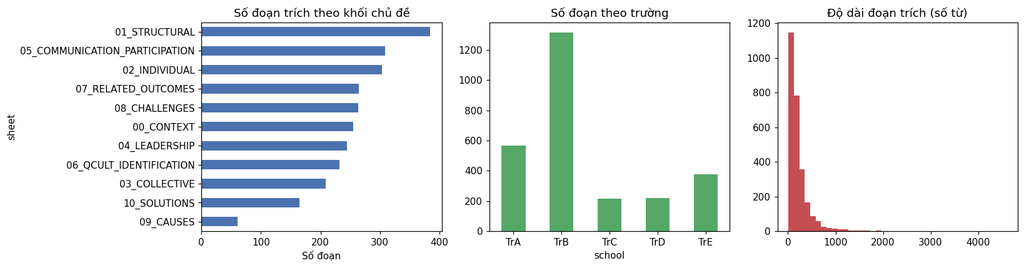

```
{
 "n_segments": 2694,
 "n_analyst_notes": 3585,
 "n_codes": 338,
 "n_sources": 24,
 "n_schools": 5,
 "n_foreign_sources": 3,
 "total_words": 563820,
 "median_words": 144.0
}
```

```python
# 2.3 Thống kê mô tả corpus
fig, axes = plt.subplots(1, 3, figsize=(15, 4))
seg.groupby('sheet').size().sort_values().plot(kind='barh', ax=axes[0], color='#4C72B0')
axes[0].set_title('Số đoạn trích theo khối chủ đề'); axes[0].set_xlabel('Số đoạn')
seg.groupby('school').size().plot(kind='bar', ax=axes[1], color='#55A868')
axes[1].set_title('Số đoạn theo trường'); axes[1].tick_params(axis='x', rotation=0)
axes[2].hist(seg.n_words, bins=40, color='#C44E52'); axes[2].set_title('Độ dài đoạn trích (số từ)')
plt.tight_layout(); plt.savefig(f'{OUT}/fig_corpus_overview.png', bbox_inches='tight'); plt.show()

corpus_stats = {'n_segments': int(len(seg)), 'n_analyst_notes': int(len(analyst)), 'n_codes': int(seg.code.nunique()),
                'n_sources': int(seg.source.nunique()), 'n_schools': int(seg.school.nunique()),
                'n_foreign_sources': int(seg[seg.is_foreign].source.nunique()),
                'total_words': int(seg.n_words.sum()), 'median_words': float(seg.n_words.median())}
print(json.dumps(corpus_stats, ensure_ascii=False, indent=1))
```

## 3. Nhúng ngữ nghĩa bằng PhoBERT

PhoBERT yêu cầu **tách từ (word segmentation)** trước khi đưa vào model — đây là bước bắt buộc, khác với BERT tiếng Anh. Ta dùng `underthesea` (hoặc `pyvi` nếu underthesea lỗi).

Chiến lược nhúng: lấy **mean pooling** trên các token của lớp ẩn cuối (có trọng số attention mask), cách được khuyến nghị cho embedding câu từ BERT.

```python
# 3.1 Tách từ tiếng Việt
try:
    from underthesea import word_tokenize as vi_tokenize
    SEGMENTER = 'underthesea'
except ImportError:
    try:
        from pyvi import ViTokenizer
        def vi_tokenize(t, format=None): return ViTokenizer.tokenize(t)
        SEGMENTER = 'pyvi'
    except ImportError:
        def vi_tokenize(t, format=None): return t
        SEGMENTER = 'NONE (fallback: không tách từ — chất lượng embedding sẽ giảm)'
print('Bộ tách từ:', SEGMENTER)

def segment_vi(t):
    try:
        r = vi_tokenize(t, format='text')
        return r if isinstance(r, str) else ' '.join(r)
    except Exception:
        return t

seg['text_seg'] = [segment_vi(t) for t in seg['text']]
print(seg[['text', 'text_seg']].head(2).to_string())
```

```
Bộ tách từ: underthesea
                                                                                                                                                                                                                                                                                                            …
0  À dạ hiện giờ thì vị trí của của em là giáo viên dạy lớp năm ừ à của [TrB]. À thời gian em công tác ở đây là đến nay là 5 năm. Trước khi chuyển đến trường này thì em đã từng công tác ở trường Công của [một quận tại TP.HCM] trong thời gian là khoảng 8 năm. À và trước đó nữa thì cũng đã từng công t…
1                                                                                                                                                                                                                                          ừ em không được xù em ha. Dạ. Ờ em hiện đang là giáo viên chủ nhi…
```

```python
# 3.2 Nạp PhoBERT và tạo embedding
import torch
from transformers import AutoModel, AutoTokenizer

device = 'cuda' if torch.cuda.is_available() else 'cpu'
print('Thiết bị:', device)

tokenizer = AutoTokenizer.from_pretrained(PHOBERT_MODEL)
model = AutoModel.from_pretrained(PHOBERT_MODEL).to(device).eval()

@torch.no_grad()
def embed_texts(texts, batch_size=16, max_length=256):
    embs = []
    for i in range(0, len(texts), batch_size):
        batch = texts[i:i+batch_size]
        enc = tokenizer(batch, padding=True, truncation=True, max_length=max_length,
                        return_tensors='pt').to(device)
        out = model(**enc).last_hidden_state           # (B, T, H)
        mask = enc['attention_mask'].unsqueeze(-1).float()
        pooled = (out * mask).sum(1) / mask.sum(1).clamp(min=1e-9)   # mean pooling
        embs.append(pooled.cpu().numpy())
        if (i // batch_size) % 20 == 0:
            print(f'  ... {i+len(batch)}/{len(texts)}', end='\r')
    return np.vstack(embs)

E = embed_texts(seg['text_seg'].tolist())
print('\nMa trận embedding:', E.shape)
np.save(f'{OUT}/embeddings_phobert.npy', E)

# Chuẩn hóa L2 để dùng cosine similarity
from sklearn.preprocessing import normalize
E_norm = normalize(E)
print('Đã lưu embedding.')
```

```
Thiết bị: cuda
```

[output not shown]

```
Ma trận embedding: (2694, 768)
Đã lưu embedding.
```

## 4. Phân cụm ngữ nghĩa & đối chiếu với hệ mã MaxQDA

Chỉ số dùng:

- **ARI (Adjusted Rand Index)** — mức trùng khớp phân hoạch, hiệu chỉnh ngẫu nhiên. 0 = ngẫu nhiên, 1 = trùng hoàn toàn.
- **NMI (Normalized Mutual Information)** — lượng thông tin chung giữa hai cách phân nhóm.
- **Purity** — tỷ lệ đoạn trong mỗi cụm AI thuộc cùng một khối chủ đề người.

Lưu ý diễn giải: ARI thấp **không có nghĩa là mã hóa người sai**. Mã hóa người dựa trên *chức năng lý thuyết* của phát ngôn; AI nhóm theo *tương đồng từ vựng - ngữ nghĩa*. Hai logic khác nhau; trùng khớp vừa phải là kỳ vọng hợp lý.

```python
# 4.1 Giảm chiều (UMAP) + phân cụm (HDBSCAN)
from sklearn.metrics import adjusted_rand_score, normalized_mutual_info_score, silhouette_score
from sklearn.cluster import KMeans

try:
    import umap
    reducer = umap.UMAP(n_neighbors=15, n_components=10, min_dist=0.0,
                        metric='cosine', random_state=RANDOM_STATE)
    E_red = reducer.fit_transform(E_norm)
    print('UMAP ->', E_red.shape)
except ImportError:
    from sklearn.decomposition import PCA
    E_red = PCA(n_components=10, random_state=RANDOM_STATE).fit_transform(E_norm)
    print('UMAP không có, dùng PCA ->', E_red.shape)

try:
    import hdbscan
    clusterer = hdbscan.HDBSCAN(min_cluster_size=25, min_samples=5, metric='euclidean',
                                cluster_selection_method='eom')
    labels_hdb = clusterer.fit_predict(E_red)
    n_hdb = len(set(labels_hdb)) - (1 if -1 in labels_hdb else 0)
    print(f'HDBSCAN: {n_hdb} cụm, {(labels_hdb==-1).sum()} đoạn nhiễu')
except ImportError:
    labels_hdb = None
    print('Chưa cài hdbscan — bỏ qua')

# KMeans với k = số khối chủ đề người (11) để so sánh trực tiếp
K = seg['sheet'].nunique()
km = KMeans(n_clusters=K, random_state=RANDOM_STATE, n_init=10)
labels_km = km.fit_predict(E_red)
seg['cluster_kmeans'] = labels_km
if labels_hdb is not None:
    seg['cluster_hdbscan'] = labels_hdb
print(f'KMeans: k = {K}')
```

```
UMAP -> (2694, 10)
HDBSCAN: 2 cụm, 0 đoạn nhiễu
KMeans: k = 11
```

```python
# 4.2 Đối chiếu AI vs mã người
human = seg['sheet'].astype('category').cat.codes.values

def purity(y_true, y_pred):
    dfp = pd.DataFrame({'t': y_true, 'p': y_pred})
    return float(dfp.groupby('p')['t'].agg(lambda s: s.value_counts().iloc[0]).sum() / len(dfp))

rows = [{'Phân cụm AI': f'KMeans (k={K})',
         'ARI': round(adjusted_rand_score(human, labels_km), 3),
         'NMI': round(normalized_mutual_info_score(human, labels_km), 3),
         'Purity': round(purity(human, labels_km), 3),
         'Silhouette': round(silhouette_score(E_red, labels_km), 3)}]
if labels_hdb is not None:
    m = labels_hdb != -1
    rows.append({'Phân cụm AI': f'HDBSCAN ({n_hdb} cụm)',
                 'ARI': round(adjusted_rand_score(human[m], labels_hdb[m]), 3),
                 'NMI': round(normalized_mutual_info_score(human[m], labels_hdb[m]), 3),
                 'Purity': round(purity(human[m], labels_hdb[m]), 3),
                 'Silhouette': round(silhouette_score(E_red[m], labels_hdb[m]), 3) if m.sum() > 10 else np.nan})
agree = pd.DataFrame(rows)
agree.to_csv(f'{OUT}/01_ai_human_agreement.csv', index=False, encoding='utf-8-sig')
print(agree.to_string(index=False))
print('\nDiễn giải: ARI 0.10-0.30 = trùng khớp vừa phải (thường gặp khi so mã lý thuyết với cụm ngữ nghĩa);')
print('           ARI > 0.40 = cấu trúc chủ đề của người được dữ liệu ủng hộ mạnh.')
```

```
    Phân cụm AI   ARI   NMI  Purity  Silhouette
  KMeans (k=11) 0.065 0.133   0.252       0.361
HDBSCAN (2 cụm) 0.000 0.002   0.143       0.867

Diễn giải: ARI 0.10-0.30 = trùng khớp vừa phải (thường gặp khi so mã lý thuyết với cụm ngữ nghĩa);
           ARI > 0.40 = cấu trúc chủ đề của người được dữ liệu ủng hộ mạnh.
```

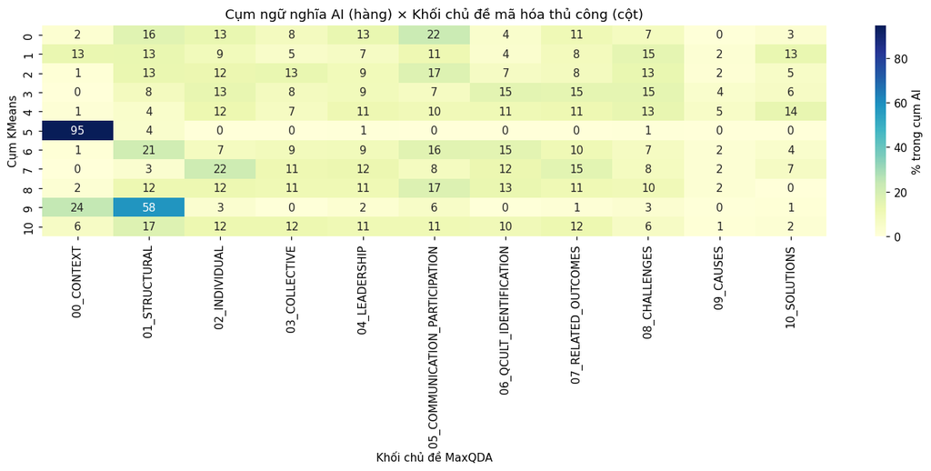

```
Cụm thuần nhất (khớp 1 khối chủ đề):
cluster_kmeans
5    94.838710
9    58.064516
0    22.265625
dtype: float64

Cụm lẫn nhất (cắt ngang nhiều khối — chỉ báo chủ đề xuyên suốt):
cluster_kmeans
3    15.047022
1    14.537445
4    13.625304
dtype: float64
```

```python
# 4.3 Ma trận chéo: cụm AI × khối chủ đề người
ct = pd.crosstab(seg['cluster_kmeans'], seg['sheet'])
ct_pct = ct.div(ct.sum(axis=1), axis=0) * 100
plt.figure(figsize=(13, 6))
sns.heatmap(ct_pct, annot=True, fmt='.0f', cmap='YlGnBu', cbar_kws={'label': '% trong cụm AI'})
plt.title('Cụm ngữ nghĩa AI (hàng) × Khối chủ đề mã hóa thủ công (cột)')
plt.ylabel('Cụm KMeans'); plt.xlabel('Khối chủ đề MaxQDA')
plt.tight_layout(); plt.savefig(f'{OUT}/fig_ai_vs_human_crosstab.png', bbox_inches='tight'); plt.show()
ct.to_csv(f'{OUT}/02_crosstab_ai_human.csv', encoding='utf-8-sig')

# Cụm AI nào "thuần" nhất và lẫn nhất
pur_by_cluster = ct_pct.max(axis=1).sort_values(ascending=False)
print('Cụm thuần nhất (khớp 1 khối chủ đề):'); print(pur_by_cluster.head(3))
print('\nCụm lẫn nhất (cắt ngang nhiều khối — chỉ báo chủ đề xuyên suốt):'); print(pur_by_cluster.tail(3))
```

```python
# 4.4 Từ khóa đặc trưng của từng cụm AI (c-TF-IDF đơn giản)
from sklearn.feature_extraction.text import TfidfVectorizer, CountVectorizer

VN_STOP = ['và','của','có','là','được','cho','các','những','một','trong','với','thì','mà','này','đó',
           'khi','để','cũng','rất','không','người','em','mình','tôi','chị','anh','cô','thầy','ạ','dạ',
           'vâng','ừ','ờ','nó','ở','ra','vào','lại','đã','sẽ','đang','nhưng','nếu','vì','nên','như']

def cluster_keywords(texts, labels, topn=8):
    docs = pd.DataFrame({'t': texts, 'l': labels}).groupby('l')['t'].apply(lambda s: ' '.join(s))
    cv = CountVectorizer(ngram_range=(1, 2), min_df=3, stop_words=VN_STOP, max_features=8000)
    X = cv.fit_transform(docs.values)
    vocab = np.array(cv.get_feature_names_out())
    tf = X.toarray().astype(float)
    tf = tf / tf.sum(axis=1, keepdims=True).clip(min=1)
    idf = np.log(1 + tf.shape[0] / (1 + (X.toarray() > 0).sum(axis=0)))
    ctfidf = tf * idf
    return {docs.index[i]: vocab[np.argsort(ctfidf[i])[::-1][:topn]].tolist() for i in range(len(docs))}

kw = cluster_keywords(seg['text_nofill'].tolist(), seg['cluster_kmeans'].values)
kw_rows = [{'Cụm': k, 'Chủ đề người chiếm ưu thế': ct_pct.loc[k].idxmax(),
            '% ưu thế': round(ct_pct.loc[k].max(), 1), 'Từ khóa đặc trưng': ', '.join(v)}
           for k, v in kw.items()]
kw_df = pd.DataFrame(kw_rows).sort_values('% ưu thế', ascending=False)
kw_df.to_csv(f'{OUT}/03_cluster_keywords.csv', index=False, encoding='utf-8-sig')
kw_df
```

|  | Cụm | Chủ đề người chiếm ưu thế | % ưu thế | Từ khóa đặc trưng |
| --- | --- | --- | --- | --- |
| 5 | 5 | 00_CONTEXT | 94.8 | ctx, trình, học, chương, chương trình, lớp, quốc, tế |
| 9 | 9 | 01_STRUCTURAL | 58.1 | cái, học, trường, qa, năm, trình, chương, chương trình |
| 0 | 0 | 05_COMMUNICATION_PARTICIPATION | 22.3 | cái, viên, trường, giáo, học, giáo viên, về, việc |
| 7 | 7 | 02_INDIVIDUAL | 21.7 | cái, trường, làm, việc, phải, về, họ, sự |
| 6 | 6 | 01_STRUCTURAL | 20.9 | cái, qa, viên, học, giáo, trường, out, giáo viên |
| 8 | 8 | 05_COMMUNICATION_PARTICIPATION | 17.2 | cái, gv_1 tra_gvthcs_, gv_1, tra_gvthcs_, tra_gvthcs_ tra_gvthcs_thpt1, tra_gvthcs_thpt1, họ, phải |
| 10 | 10 | 01_STRUCTURAL | 17.0 | the, and, we, of, to, it, be, is |
| 2 | 2 | 05_COMMUNICATION_PARTICIPATION | 16.9 | cái, họ, trường, làm, về, viên, giáo, học |
| 3 | 3 | 06_QCULT_IDENTIFICATION | 15.0 | cái, trường, họ, làm, phải, học, viên, về |
| 1 | 1 | 08_CHALLENGES | 14.5 | the, and, we, to, in, is, of, school |
| 4 | 4 | 10_SOLUTIONS | 13.6 | cái, họ, phải, làm, rồi, trường, học, ta |

## 5. Mô hình chủ đề BERTopic

BERTopic dùng chính embedding PhoBERT để phát hiện chủ đề, cho phép so sánh **chủ đề nổi lên tự động** với **hệ mã lý thuyết**. Điểm mạnh so với LDA: hiểu ngữ cảnh, không cần định trước số chủ đề.

```python
# 5.1 BERTopic trên embedding PhoBERT
try:
    from bertopic import BERTopic
    from bertopic.vectorizers import ClassTfidfTransformer
    from sklearn.feature_extraction.text import CountVectorizer

    vectorizer = CountVectorizer(ngram_range=(1, 2), min_df=1, stop_words=VN_STOP) # Changed min_df from 5 to 1
    topic_model = BERTopic(
        embedding_model=None,                      # dùng embedding có sẵn
        vectorizer_model=vectorizer,
        ctfidf_model=ClassTfidfTransformer(reduce_frequent_words=True),
        min_topic_size=25, nr_topics='auto', calculate_probabilities=False,
        verbose=False)
    topics, _ = topic_model.fit_transform(seg['text_nofill'].tolist(), embeddings=E_norm)
    seg['bertopic'] = topics

    tinfo = topic_model.get_topic_info()
    tinfo.to_csv(f'{OUT}/04_bertopic_topics.csv', index=False, encoding='utf-8-sig')
    print(f"BERTopic: {len(tinfo)-1} chủ đề (+ nhiễu). Top 12:")
    display(tinfo.head(13)[['Topic', 'Count', 'Name']])
except ImportError:
    print('Chưa cài bertopic — bỏ qua phần 5. Cài: pip install bertopic')
    topic_model = None
```

```
BERTopic: 1 chủ đề (+ nhiễu). Top 12:
```

|  | Topic | Count | Name |
| --- | --- | --- | --- |
| 0 | 0 | 2367 | 0_ci_mnh_nh_khng |
| 1 | 1 | 327 | 1_the_and_to_that |

```python
# 5.2 Chủ đề BERTopic × khối chủ đề người + × trường
if topic_model is not None:
    tt = seg[seg.bertopic >= 0]
    ct2 = pd.crosstab(tt['bertopic'], tt['sheet'])
    ct2.to_csv(f'{OUT}/05_bertopic_vs_human.csv', encoding='utf-8-sig')

    # chủ đề nào phân bố lệch theo trường -> chỉ báo phân kỳ liên trường
    ct3 = pd.crosstab(tt['bertopic'], tt['school'], normalize='index') * 100
    from scipy.stats import entropy
    ct3['Độ tập trung (1-entropy chuẩn hóa)'] = 1 - ct3.apply(
        lambda r: entropy(r.values + 1e-9) / np.log(len(r)), axis=1)
    div = ct3.sort_values('Độ tập trung (1-entropy chuẩn hóa)', ascending=False)
    div.round(2).to_csv(f'{OUT}/06_bertopic_school_divergence.csv', encoding='utf-8-sig')
    print('Chủ đề đặc thù nhất theo trường (phân kỳ cao):')
    for t in div.head(5).index:
        name = tinfo.loc[tinfo.Topic == t, 'Name'].values
        print(f'  Topic {t}: {name[0] if len(name) else ""} | tập trung = {div.loc[t].iloc[-1]:.2f}')
    display(div.head(8).round(1))
```

```
Chủ đề đặc thù nhất theo trường (phân kỳ cao):
  Topic 1: 1_the_and_to_that | tập trung = 1.00
  Topic 0: 0_ci_mnh_nh_khng | tập trung = 0.11
```

| school bertopic | TrA | TrB | TrC | TrD | TrE | Độ tập trung (1-entropy chuẩn hóa) |
| --- | --- | --- | --- | --- | --- | --- |
| 1 | 0.0 | 100.0 | 0.0 | 0.0 | 0.0 | 1.0 |
| 0 | 23.9 | 41.9 | 9.1 | 9.2 | 15.9 | 0.1 |

## 6. Phân tích cảm xúc (sentiment)

Mục đích không phải "đo cảm xúc" chung chung, mà trả lời câu hỏi có ý nghĩa quản lý: **những mã nào được nói đến với giọng điệu tiêu cực nhất?** và **giáo viên nước ngoài có diễn ngôn tiêu cực hơn không?** — đây là kiểm chứng định tính cho khoảng cách d = 2,08 tìm thấy ở phân tích định lượng.

```python
# 6.1 Sentiment bằng model PhoBERT fine-tuned
try:
    from transformers import AutoModelForSequenceClassification, pipeline
    sent_tok = AutoTokenizer.from_pretrained(SENTIMENT_MODEL)
    sent_mod = AutoModelForSequenceClassification.from_pretrained(SENTIMENT_MODEL)
    sent_pipe = pipeline('sentiment-analysis', model=sent_mod, tokenizer=sent_tok,
                         device=0 if device == 'cuda' else -1, truncation=True, max_length=256)

    texts_for_sent = seg['text_seg'].tolist()
    preds = []
    B = 32
    for i in range(0, len(texts_for_sent), B):
        preds.extend(sent_pipe(texts_for_sent[i:i+B]))
        if (i // B) % 20 == 0: print(f'  ... {i}/{len(texts_for_sent)}', end='\r')
    seg['sent_label'] = [p['label'] for p in preds]
    seg['sent_score'] = [p['score'] for p in preds]
    # quy về thang -1..1
    lab_map = {'NEG': -1, 'NEGATIVE': -1, 'NEU': 0, 'NEUTRAL': 0, 'POS': 1, 'POSITIVE': 1}
    seg['sent_val'] = seg['sent_label'].str.upper().map(lab_map).fillna(0) * seg['sent_score']
    print('\nPhân bố nhãn cảm xúc:'); print(seg.sent_label.value_counts())
    SENT_OK = True
except Exception as e:
    print('Không nạp được model sentiment:', e)
    print('Gợi ý thay thế: 5CD-AI/Vietnamese-Sentiment-visobert hoặc tự gán nhãn thủ công mẫu 200 đoạn.')
    SENT_OK = False
```

```
  ... 0/2694
```

```
[transformers] You seem to be using the pipelines sequentially on GPU. In order to maximize efficiency please use a dataset
```

```
Phân bố nhãn cảm xúc:
sent_label
POS    1157
NEG    1131
NEU     406
Name: count, dtype: int64
```

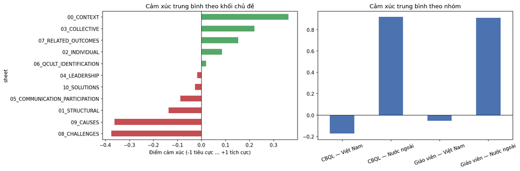

```
Việt Nam M = -0.127 (n=2366) | Nước ngoài M = 0.916 (n=328)
t = -48.57, p = 0.0000, Cohen d = -1.76

>>> ĐỐI CHIẾU ĐỊNH LƯỢNG: khảo sát cho d = 2,08 ở cảm nhận VHCL giữa hai nhóm.
    Nếu sentiment cũng lệch cùng chiều, đây là bằng chứng hội tụ (convergent validity) giữa hai nguồn dữ liệu.

10 mã có giọng điệu tiêu cực nhất:
```

| code | n | sent |
| --- | --- | --- |
| COMM-BARRIER | 10 | -0.765 |
| CHAL-DECISION | 9 | -0.718 |
| CAUSE-LEADERSHIP | 12 | -0.715 |
| QA-EVIDENCE | 12 | -0.707 |
| COMMIT-EXTRA | 9 | -0.681 |
| LEAD-LACK-RECOG | 8 | -0.610 |
| COMM-RESPOND | 12 | -0.604 |
| QCULT-A-INDECISIVE | 10 | -0.589 |
| SOL-GOV-MECH | 9 | -0.553 |
| CHAL-SUSTAIN | 14 | -0.519 |

```python
# 6.2 Cảm xúc theo khối chủ đề và theo nhóm
if SENT_OK:
    fig, axes = plt.subplots(1, 2, figsize=(15, 5))
    by_sheet = seg.groupby('sheet')['sent_val'].mean().sort_values()
    by_sheet.plot(kind='barh', ax=axes[0],
                  color=['#C44E52' if v < 0 else '#55A868' for v in by_sheet])
    axes[0].axvline(0, color='k', lw=.8); axes[0].set_title('Cảm xúc trung bình theo khối chủ đề')
    axes[0].set_xlabel('Điểm cảm xúc (-1 tiêu cực … +1 tích cực)')

    grp = seg.groupby(['role', 'is_foreign'])['sent_val'].agg(['mean', 'count'])
    grp.index = [f'{r} — {"Nước ngoài" if f else "Việt Nam"}' for r, f in grp.index]
    grp['mean'].plot(kind='bar', ax=axes[1], color='#4C72B0')
    axes[1].axhline(0, color='k', lw=.8); axes[1].set_title('Cảm xúc trung bình theo nhóm')
    axes[1].tick_params(axis='x', rotation=20)
    plt.tight_layout(); plt.savefig(f'{OUT}/fig_sentiment.png', bbox_inches='tight'); plt.show()

    # Kiểm định khác biệt Việt vs nước ngoài
    from scipy import stats as st
    a = seg.loc[~seg.is_foreign, 'sent_val']; b = seg.loc[seg.is_foreign, 'sent_val']
    t, p = st.ttest_ind(a, b, equal_var=False)
    d_val = (a.mean() - b.mean()) / np.sqrt((a.var() + b.var()) / 2)
    print(f'Việt Nam M = {a.mean():.3f} (n={len(a)}) | Nước ngoài M = {b.mean():.3f} (n={len(b)})')
    print(f't = {t:.2f}, p = {p:.4f}, Cohen d = {d_val:.2f}')
    print('\n>>> ĐỐI CHIẾU ĐỊNH LƯỢNG: khảo sát cho d = 2,08 ở cảm nhận VHCL giữa hai nhóm.')
    print('    Nếu sentiment cũng lệch cùng chiều, đây là bằng chứng hội tụ (convergent validity) giữa hai nguồn dữ liệu.')

    sent_by_code = seg.groupby('code').agg(n=('sent_val','size'), sent=('sent_val','mean')).query('n >= 8')
    sent_by_code.sort_values('sent').round(3).to_csv(f'{OUT}/07_sentiment_by_code.csv', encoding='utf-8-sig')
    print('\n10 mã có giọng điệu tiêu cực nhất:'); display(sent_by_code.sort_values('sent').head(10).round(3))
```

## 7. Mạng lưới đồng xuất hiện mã

Hai mã "đồng xuất hiện" khi cùng được gán cho một nguồn (người trả lời). Mạng lưới này cho thấy **cấu trúc lập luận** trong dữ liệu: mã nào là trung tâm, mã nào là cầu nối giữa các cụm chủ đề — thông tin mà bảng tần suất không thể hiện được.

```python
# 7.1 Xây dựng mạng đồng xuất hiện
import networkx as nx
from itertools import combinations

inc = pd.crosstab(seg['source'], seg['code'])
inc = (inc > 0).astype(int)
co = inc.T.dot(inc)
np.fill_diagonal(co.values, 0)

MIN_CO = 3
G = nx.Graph()
for c in co.columns:
    G.add_node(c, block=seg.loc[seg.code == c, 'sheet'].mode().iloc[0] if (seg.code == c).any() else '')
for a, b in combinations(co.columns, 2):
    w = int(co.loc[a, b])
    if w >= MIN_CO:
        G.add_edge(a, b, weight=w)
G.remove_nodes_from([n for n, d in G.degree() if d == 0])
print(f'Mạng: {G.number_of_nodes()} mã, {G.number_of_edges()} liên kết (ngưỡng đồng xuất hiện ≥ {MIN_CO})')

deg = nx.degree_centrality(G)
btw = nx.betweenness_centrality(G, weight='weight')
eig = nx.eigenvector_centrality(G, weight='weight', max_iter=1000)
cent = pd.DataFrame({'Degree': deg, 'Betweenness': btw, 'Eigenvector': eig})
cent['Khối chủ đề'] = [G.nodes[n].get('block', '') for n in cent.index]
cent = cent.sort_values('Eigenvector', ascending=False)
cent.round(4).to_csv(f'{OUT}/08_code_network_centrality.csv', encoding='utf-8-sig')
print('\n15 mã trung tâm nhất (eigenvector — mã kết nối với các mã quan trọng khác):')
display(cent.head(15).round(3))
print('\n10 mã cầu nối (betweenness — nối các cụm chủ đề khác nhau):')
display(cent.sort_values('Betweenness', ascending=False).head(10).round(3))
```

```
Mạng: 277 mã, 21288 liên kết (ngưỡng đồng xuất hiện ≥ 3)

15 mã trung tâm nhất (eigenvector — mã kết nối với các mã quan trọng khác):
```

|  | Degree | Betweenness | Eigenvector | Khối chủ đề |
| --- | --- | --- | --- | --- |
| VALUE-SHARED | 1.000 | 0.001 | 0.135 | 03_COLLECTIVE |
| CTX-TENURE-SCHOOL | 1.000 | 0.001 | 0.135 | 00_CONTEXT |
| TRUST-COLLEAGUE | 0.978 | 0.001 | 0.130 | 03_COLLECTIVE |
| CTX-ROLE | 0.989 | 0.001 | 0.130 | 00_CONTEXT |
| CTX-STUDENTS | 0.978 | 0.001 | 0.125 | 00_CONTEXT |
| LEAD-SUPPORT | 0.986 | 0.002 | 0.125 | 04_LEADERSHIP |
| OUT-DISSAT | 0.982 | 0.001 | 0.124 | 07_RELATED_OUTCOMES |
| CTX-PROGRAM | 0.949 | 0.001 | 0.123 | 00_CONTEXT |
| OUT-PD-EFFECT | 0.960 | 0.001 | 0.121 | 07_RELATED_OUTCOMES |
| OUT-JOB-SAT | 0.960 | 0.001 | 0.120 | 07_RELATED_OUTCOMES |
| QA-GOAL-COMM | 0.960 | 0.001 | 0.120 | 01_STRUCTURAL |
| QA-GOAL-AWARE | 0.964 | 0.002 | 0.119 | 01_STRUCTURAL |
| TRUST-SUPPORT | 0.946 | 0.002 | 0.119 | 03_COLLECTIVE |
| COMMIT-QUALITY | 0.928 | 0.001 | 0.118 | 02_INDIVIDUAL |
| PART-VOICE | 0.960 | 0.002 | 0.118 | 05_COMMUNICATION_PARTICIPATION |

```
10 mã cầu nối (betweenness — nối các cụm chủ đề khác nhau):
```

|  | Degree | Betweenness | Eigenvector | Khối chủ đề |
| --- | --- | --- | --- | --- |
| LEAD-FEEDBACK-USEFUL | 0.688 | 0.006 | 0.050 | 04_LEADERSHIP |
| CHAL-PD | 0.569 | 0.005 | 0.038 | 08_CHALLENGES |
| ENG-STUDENT | 0.475 | 0.005 | 0.030 | 02_INDIVIDUAL |
| COMM-BGH-GV | 0.601 | 0.005 | 0.044 | 05_COMMUNICATION_PARTICIPATION |
| QCULT-ACTION | 0.286 | 0.005 | 0.016 | 06_QCULT_IDENTIFICATION |
| CHAL-DECISION | 0.659 | 0.005 | 0.049 | 08_CHALLENGES |
| LEAD-CONNECT-SOLUTION | 0.551 | 0.005 | 0.041 | 04_LEADERSHIP |
| CHAL-LEAD-SUPPORT | 0.576 | 0.005 | 0.040 | 08_CHALLENGES |
| LEAD-EMPOWER | 0.674 | 0.004 | 0.054 | 04_LEADERSHIP |
| COMM-PARENT-DIALOGUE | 0.743 | 0.004 | 0.062 | 05_COMMUNICATION_PARTICIPATION |

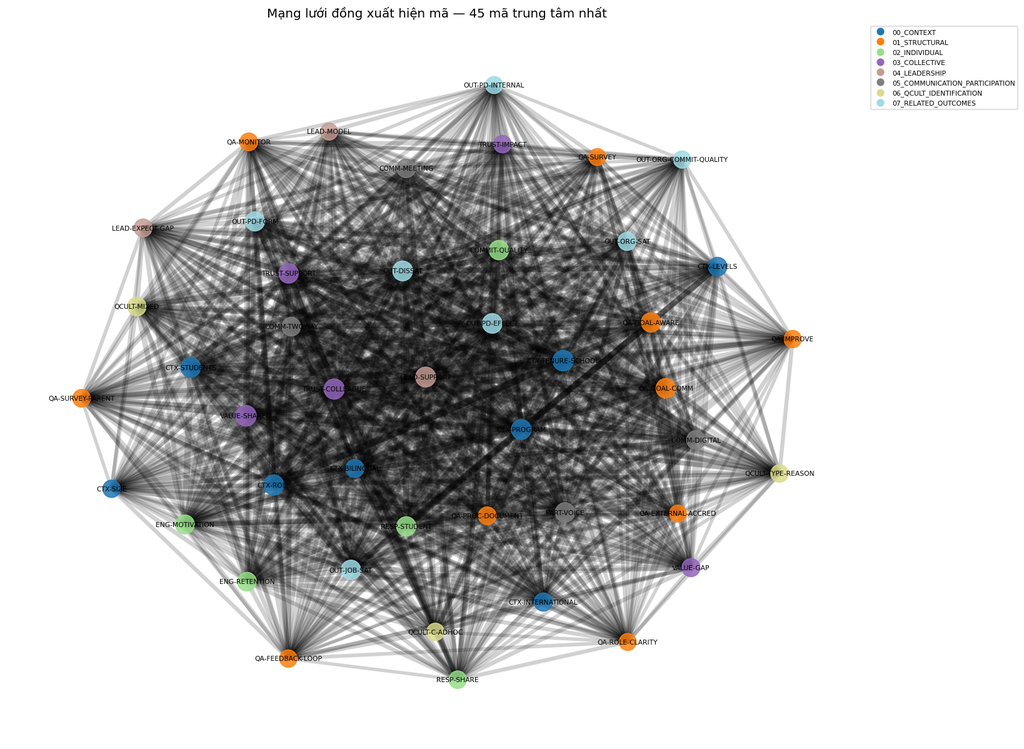

```
Phát hiện 2 cộng đồng mã (modularity). So với 11 khối chủ đề lý thuyết.
  Cộng đồng 0 (145 mã): chủ đạo = 10_SOLUTIONS (22/145 mã)
  Cộng đồng 1 (132 mã): chủ đạo = 08_CHALLENGES (21/132 mã)
```

```python
# 7.2 Trực quan hóa mạng (chỉ các mã trung tâm)
top_nodes = cent.head(45).index.tolist()
H = G.subgraph(top_nodes)
pos = nx.spring_layout(H, k=.5, seed=RANDOM_STATE, weight='weight')
blocks = sorted({H.nodes[n].get('block', '') for n in H.nodes})
cmap = {b: plt.cm.tab20(i / max(len(blocks) - 1, 1)) for i, b in enumerate(blocks)}

plt.figure(figsize=(15, 11))
nx.draw_networkx_edges(H, pos, alpha=.18,
                       width=[H[u][v]['weight'] * .35 for u, v in H.edges])
nx.draw_networkx_nodes(H, pos,
                       node_size=[3000 * cent.loc[n, 'Eigenvector'] + 60 for n in H.nodes],
                       node_color=[cmap[H.nodes[n].get('block', '')] for n in H.nodes], alpha=.85)
nx.draw_networkx_labels(H, pos, font_size=7)
handles = [plt.Line2D([0], [0], marker='o', color='w', markerfacecolor=cmap[b], markersize=9, label=b) for b in blocks]
plt.legend(handles=handles, fontsize=7, loc='upper left', bbox_to_anchor=(1, 1))
plt.title('Mạng lưới đồng xuất hiện mã — 45 mã trung tâm nhất', fontsize=13)
plt.axis('off'); plt.tight_layout()
plt.savefig(f'{OUT}/fig_code_network.png', bbox_inches='tight', dpi=140); plt.show()

# Phát hiện cộng đồng (community) — so với khối chủ đề lý thuyết
try:
    from networkx.algorithms.community import greedy_modularity_communities
    comms = list(greedy_modularity_communities(G, weight='weight'))
    print(f'Phát hiện {len(comms)} cộng đồng mã (modularity). So với {seg.sheet.nunique()} khối chủ đề lý thuyết.')
    for i, c in enumerate(comms[:6]):
        blocks_in = pd.Series([G.nodes[n].get('block','') for n in c]).value_counts()
        print(f'  Cộng đồng {i} ({len(c)} mã): chủ đạo = {blocks_in.index[0]} ({blocks_in.iloc[0]}/{len(c)} mã)')
except Exception as e:
    print('Bỏ qua community detection:', e)
```

## 8. Hội tụ - phân kỳ liên trường (lượng hóa)

Workbook MaxQDA đã có phân tích hội tụ/phân kỳ thủ công. Phần này **lượng hóa** nó: với mỗi mã, tính độ phủ trường và chỉ số phân kỳ, để xác định đâu là **mẫu hình chung của hệ thống** và đâu là **đặc thù từng trường** — cơ sở cho khuyến nghị chính sách.

```python
# 8.1 Ma trận mã × trường
cs = pd.crosstab(seg['code'], seg['school'])
cs['Số trường có mã'] = (cs > 0).sum(axis=1)
cs['Tổng đoạn'] = cs.iloc[:, :-1].sum(axis=1)

n_schools = seg['school'].nunique()
prop = cs.iloc[:, :n_schools].div(cs['Tổng đoạn'], axis=0).fillna(0)
from scipy.stats import entropy
cs['Chỉ số phân kỳ'] = 1 - prop.apply(lambda r: entropy(r.values + 1e-12) / np.log(n_schools), axis=1)

conv = cs[(cs['Số trường có mã'] >= 4) & (cs['Tổng đoạn'] >= 6)].sort_values('Tổng đoạn', ascending=False)
dive = cs[(cs['Số trường có mã'] <= 2) & (cs['Tổng đoạn'] >= 5)].sort_values('Chỉ số phân kỳ', ascending=False)

cs.round(3).to_csv(f'{OUT}/09_code_school_matrix.csv', encoding='utf-8-sig')
print(f'MÃ HỘI TỤ (xuất hiện ở ≥4/{n_schools} trường): {len(conv)} mã — mẫu hình chung của hệ thống')
display(conv.head(15))
print(f'\nMÃ PHÂN KỲ (chỉ ở ≤2 trường): {len(dive)} mã — đặc thù bối cảnh')
display(dive.head(12))
```

```
MÃ HỘI TỤ (xuất hiện ở ≥4/5 trường): 144 mã — mẫu hình chung của hệ thống
```

| school code | TrA | TrB | TrC | TrD | TrE | Số trường có mã | Tổng đoạn | Chỉ số phân kỳ |
| --- | --- | --- | --- | --- | --- | --- | --- | --- |
| VALUE-SHARED | 5 | 12 | 2 | 2 | 3 | 5 | 24 | 0.162782 |
| CTX-TENURE-SCHOOL | 5 | 12 | 2 | 2 | 3 | 5 | 24 | 0.162782 |
| CTX-ROLE | 4 | 12 | 2 | 2 | 3 | 5 | 23 | 0.171088 |
| TRUST-COLLEAGUE | 4 | 12 | 2 | 2 | 3 | 5 | 23 | 0.171088 |
| CTX-PROGRAM | 5 | 10 | 2 | 2 | 3 | 5 | 22 | 0.128395 |
| CTX-STUDENTS | 5 | 11 | 2 | 2 | 2 | 5 | 22 | 0.169105 |
| LEAD-SUPPORT | 5 | 11 | 1 | 2 | 3 | 5 | 22 | 0.183883 |
| OUT-DISSAT | 5 | 11 | 2 | 1 | 3 | 5 | 22 | 0.183883 |
| OUT-JOB-SAT | 4 | 11 | 1 | 2 | 3 | 5 | 21 | 0.191353 |
| COMMIT-QUALITY | 5 | 11 | 1 | 2 | 2 | 5 | 21 | 0.208882 |
| PART-VOICE | 4 | 10 | 2 | 2 | 3 | 5 | 21 | 0.133222 |
| QA-GOAL-COMM | 3 | 11 | 2 | 2 | 3 | 5 | 21 | 0.165818 |
| TRUST-SUPPORT | 3 | 12 | 2 | 2 | 2 | 5 | 21 | 0.211160 |
| RESP-STUDENT | 4 | 10 | 2 | 2 | 3 | 5 | 21 | 0.133222 |
| QA-GOAL-AWARE | 5 | 10 | 2 | 1 | 3 | 5 | 21 | 0.166234 |

```
MÃ PHÂN KỲ (chỉ ở ≤2 trường): 16 mã — đặc thù bối cảnh
```

| school code | TrA | TrB | TrC | TrD | TrE | Số trường có mã | Tổng đoạn | Chỉ số phân kỳ |
| --- | --- | --- | --- | --- | --- | --- | --- | --- |
| QA-GOAL-BINDING | 0 | 5 | 0 | 0 | 0 | 1 | 5 | 1.000000 |
| GOV-MECH | 1 | 10 | 0 | 0 | 0 | 2 | 11 | 0.810719 |
| CAUSE-GOVERNANCE | 0 | 9 | 0 | 0 | 1 | 2 | 10 | 0.798015 |
| OUT-CULTURE-SAT | 0 | 6 | 0 | 0 | 1 | 2 | 7 | 0.745180 |
| SOL-COLLAB-CROSS | 0 | 6 | 0 | 0 | 1 | 2 | 7 | 0.745180 |
| SOL-PD-PLAN | 1 | 6 | 0 | 0 | 0 | 2 | 7 | 0.745180 |
| TRUST-LEVEL-MID | 0 | 5 | 0 | 0 | 1 | 2 | 6 | 0.720051 |
| SOL-LEAD-CLEAR | 0 | 4 | 1 | 0 | 0 | 2 | 5 | 0.689082 |
| SOL-LEAD-SUPPORT | 0 | 4 | 1 | 0 | 0 | 2 | 5 | 0.689082 |
| VALUE-INDIVIDUAL | 1 | 4 | 0 | 0 | 0 | 2 | 5 | 0.689082 |
| OUT-WORK-ENV | 0 | 6 | 2 | 0 | 0 | 2 | 8 | 0.650602 |
| CHAL-LEAD-UNCLEAR | 2 | 5 | 0 | 0 | 0 | 2 | 7 | 0.628274 |

```python
# 8.1b Đối chiếu với phân tích hội tụ/phân kì THỦ CÔNG của NCS
# NCS đã viết sẵn các cột 'Điểm hội tụ liên trường' / 'Điểm phân kì liên trường'.
# Kiểm chứng: kết luận thủ công có khớp với chỉ số định lượng vừa tính không?
conv_manual = analyst[analyst.source.str.contains('hội tụ', case=False, na=False)]
dive_manual = analyst[analyst.source.str.contains('phân kì', case=False, na=False)]
print(f'NCS ghi nhận thủ công: {len(conv_manual)} nhận định hội tụ, {len(dive_manual)} nhận định phân kì')

cm, dm = set(conv_manual.code.unique()), set(dive_manual.code.unique())
ca, da = set(conv.index), set(dive.index)
overlap = pd.DataFrame([
 {'Loại':'Hội tụ','Thủ công (NCS)':len(cm),'Tự động (chỉ số)':len(ca),'Trùng nhau':len(cm&ca),
  'Tỷ lệ trùng (%)':round(100*len(cm&ca)/max(len(ca),1),1)},
 {'Loại':'Phân kì','Thủ công (NCS)':len(dm),'Tự động (chỉ số)':len(da),'Trùng nhau':len(dm&da),
  'Tỷ lệ trùng (%)':round(100*len(dm&da)/max(len(da),1),1)}])
overlap.to_csv(f'{OUT}/09b_manual_vs_auto_convergence.csv', index=False, encoding='utf-8-sig')
display(overlap)
print('\nĐây là kiểm định độ tin cậy: chỉ số tự động có tái hiện phán đoán của NCS không?')
```

```
NCS ghi nhận thủ công: 794 nhận định hội tụ, 1199 nhận định phân kì
```

|  | Loại | Thủ công (NCS) | Tự động (chỉ số) | Trùng nhau | Tỷ lệ trùng (%) |
| --- | --- | --- | --- | --- | --- |
| 0 | Hội tụ | 397 | 144 | 144 | 100.0 |
| 1 | Phân kì | 397 | 16 | 16 | 100.0 |

```
Đây là kiểm định độ tin cậy: chỉ số tự động có tái hiện phán đoán của NCS không?
```

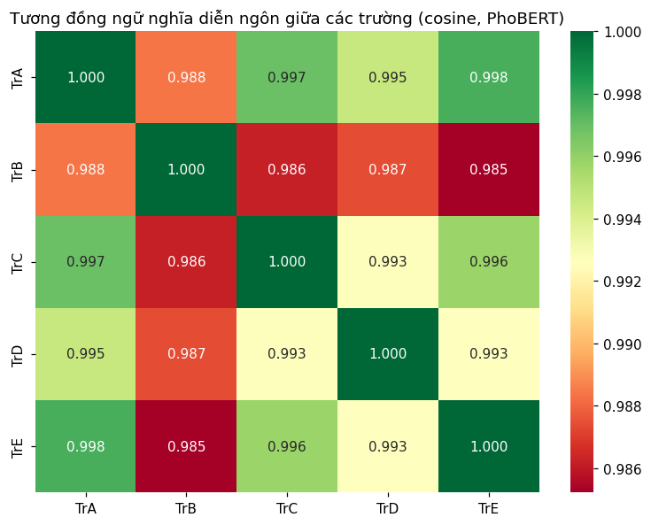

```
Cặp trường giống nhau nhất : ('TrA', 'TrE') = 0.998
Cặp trường khác nhau nhất  : ('TrB', 'TrE') = 0.985
```

```python
# 8.2 Hồ sơ ngữ nghĩa từng trường (dựa trên embedding)
school_prof = {}
for s in sorted(seg['school'].dropna().unique()):
    idx = seg.index[seg.school == s]
    school_prof[s] = E_norm[idx].mean(axis=0)
SP = pd.DataFrame(school_prof).T
from sklearn.metrics.pairwise import cosine_similarity
sim = pd.DataFrame(cosine_similarity(SP), index=SP.index, columns=SP.index)

plt.figure(figsize=(7, 5.5))
sns.heatmap(sim, annot=True, fmt='.3f', cmap='RdYlGn', vmin=sim.values[sim.values<1].min(), vmax=1)
plt.title('Tương đồng ngữ nghĩa diễn ngôn giữa các trường (cosine, PhoBERT)')
plt.tight_layout(); plt.savefig(f'{OUT}/fig_school_similarity.png', bbox_inches='tight'); plt.show()
sim.round(4).to_csv(f'{OUT}/10_school_semantic_similarity.csv', encoding='utf-8-sig')

tri = sim.where(~np.eye(len(sim), dtype=bool))
print(f'Cặp trường giống nhau nhất : {tri.stack().idxmax()} = {tri.stack().max():.3f}')
print(f'Cặp trường khác nhau nhất  : {tri.stack().idxmin()} = {tri.stack().min():.3f}')
```

## 9. So sánh diễn ngôn: giáo viên Việt Nam vs giáo viên nước ngoài

Đây là phần **quan trọng nhất cho tích hợp mixed methods**. Phân tích định lượng phát hiện khoảng cách rất lớn (Cohen's d = 2,08 ở cảm nhận VHCL). Câu hỏi: dữ liệu định tính có giải thích được khoảng cách đó không, và bằng cơ chế gì?

```python
# 9.1 Mã đặc trưng cho từng nhóm (log-odds ratio với prior thông tin)
def log_odds_ratio(counts_a, counts_b, alpha=1.0):
    """Monroe et al. (2008) — fightin' words: log-odds-ratio với prior Dirichlet."""
    all_codes = sorted(set(counts_a.index) | set(counts_b.index))
    a = counts_a.reindex(all_codes).fillna(0) + alpha
    b = counts_b.reindex(all_codes).fillna(0) + alpha
    la = np.log(a / (a.sum() - a)); lb = np.log(b / (b.sum() - b))
    delta = la - lb
    var = 1 / a + 1 / b
    return pd.DataFrame({'delta': delta, 'z': delta / np.sqrt(var)}).sort_values('z')

vn = seg[~seg.is_foreign]['code'].value_counts()
nn = seg[seg.is_foreign]['code'].value_counts()
lor = log_odds_ratio(nn, vn)   # dương = đặc trưng nhóm nước ngoài
lor['Khối'] = [seg.loc[seg.code == c, 'sheet'].mode().iloc[0] if (seg.code == c).any() else '' for c in lor.index]
lor.round(3).to_csv(f'{OUT}/11_discourse_foreign_vs_vn.csv', encoding='utf-8-sig')

print('>>> Mã ĐẶC TRƯNG cho giáo viên NƯỚC NGOÀI (nói nhiều hơn hẳn):')
display(lor.sort_values('z', ascending=False).head(15).round(2))
print('\n>>> Mã ĐẶC TRƯNG cho giáo viên VIỆT NAM:')
display(lor.head(15).round(2))
```

```
>>> Mã ĐẶC TRƯNG cho giáo viên NƯỚC NGOÀI (nói nhiều hơn hẳn):
```

| code | delta | z | Khối |
| --- | --- | --- | --- |
| LEAD-HIERARCHY | 1.41 | 1.99 | 04_LEADERSHIP |
| CHAL-TOOL | 1.81 | 1.98 | 08_CHALLENGES |
| CHAL-CONFLICT | 1.81 | 1.98 | 08_CHALLENGES |
| SOL-CONSTRUCTIVE | 1.81 | 1.98 | 10_SOLUTIONS |
| SOL-PD-PLAN | 1.18 | 1.76 | 10_SOLUTIONS |
| PART-PLAN | 1.40 | 1.72 | 05_COMMUNICATION_PARTICIPATION |
| QCULT-ACTION | 1.40 | 1.72 | 06_QCULT_IDENTIFICATION |
| COMM-MIDDLE-GV | 2.10 | 1.71 | 05_COMMUNICATION_PARTICIPATION |
| SOL-QA-DATA | 2.10 | 1.71 | 10_SOLUTIONS |
| CHAL-OPENNESS | 2.10 | 1.71 | 08_CHALLENGES |
| LEAD-TEAM-SUPPORT | 1.00 | 1.55 | 04_LEADERSHIP |
| SOL-STUDENT-QUALITY | 1.12 | 1.46 | 10_SOLUTIONS |
| SOL-TRUST | 1.12 | 1.46 | 10_SOLUTIONS |
| SOL-INTERNATIONAL | 1.12 | 1.46 | 10_SOLUTIONS |
| SOL-LEAD-SUPPORT | 1.12 | 1.46 | 10_SOLUTIONS |

```
>>> Mã ĐẶC TRƯNG cho giáo viên VIỆT NAM:
```

| code | delta | z | Khối |
| --- | --- | --- | --- |
| OUT-ORG-SAT | -1.49 | -1.45 | 07_RELATED_OUTCOMES |
| QCULT-TYPE-REASON | -1.44 | -1.40 | 06_QCULT_IDENTIFICATION |
| OWNERSHIP | -1.38 | -1.33 | 02_INDIVIDUAL |
| TRUST-LEADER | -1.38 | -1.33 | 03_COLLECTIVE |
| LEAD-EXPECT-QUALITY | -1.24 | -1.20 | 04_LEADERSHIP |
| ENG-ORG | -1.24 | -1.20 | 02_INDIVIDUAL |
| QCULT-MIXED | -0.85 | -1.15 | 06_QCULT_IDENTIFICATION |
| CAUSE-LEADERSHIP | -1.17 | -1.12 | 09_CAUSES |
| QVAL-RECOGNITION | -1.17 | -1.12 | 06_QCULT_IDENTIFICATION |
| QA-COMPLIANCE | -1.17 | -1.12 | 01_STRUCTURAL |
| OUT-POLICY-SAT | -1.17 | -1.12 | 07_RELATED_OUTCOMES |
| QA-EVIDENCE | -1.17 | -1.12 | 01_STRUCTURAL |
| COMM-RESPOND | -1.17 | -1.12 | 05_COMMUNICATION_PARTICIPATION |
| COMM-LISTEN | -1.17 | -1.12 | 05_COMMUNICATION_PARTICIPATION |
| QVAL-PRIORITY-TOP5 | -1.09 | -1.04 | 06_QCULT_IDENTIFICATION |

```python
# 9.2 Khoảng cách ngữ nghĩa và trực quan hóa không gian diễn ngôn
prof_vn = E_norm[seg.index[~seg.is_foreign]].mean(axis=0)
prof_nn = E_norm[seg.index[seg.is_foreign]].mean(axis=0)
cos_gap = float(cosine_similarity([prof_vn], [prof_nn])[0, 0])
print(f'Tương đồng ngữ nghĩa VN vs Nước ngoài: {cos_gap:.4f}  (càng thấp = diễn ngôn càng khác biệt)')

# So sánh với khoảng cách giữa hai nhóm ngẫu nhiên cùng cỡ (kiểm định hoán vị)
rng = np.random.default_rng(RANDOM_STATE)
n_nn = int(seg.is_foreign.sum())
perm = []
for _ in range(500):
    idx = rng.permutation(len(seg))
    p1 = E_norm[idx[:n_nn]].mean(axis=0); p2 = E_norm[idx[n_nn:]].mean(axis=0)
    perm.append(float(cosine_similarity([p1], [p2])[0, 0]))
p_val = float(np.mean(np.array(perm) <= cos_gap))
print(f'Kiểm định hoán vị (500 lần): p = {p_val:.4f}')
print('  -> p < .05 nghĩa là diễn ngôn hai nhóm khác biệt hơn mức ngẫu nhiên.')

if 'sent_val' in seg.columns:
    comp = seg.groupby('is_foreign').agg(n=('sent_val','size'), sentiment=('sent_val','mean')).round(3)
    comp.index = ['Việt Nam', 'Nước ngoài']
    display(comp)

json.dump({'cosine_vn_vs_foreign': cos_gap, 'permutation_p': p_val,
           'n_foreign_segments': n_nn, 'n_vn_segments': int(len(seg) - n_nn)},
          open(f'{OUT}/12_discourse_gap.json', 'w', encoding='utf-8'), ensure_ascii=False, indent=1)
```

```
Tương đồng ngữ nghĩa VN vs Nước ngoài: 0.7993  (càng thấp = diễn ngôn càng khác biệt)
Kiểm định hoán vị (500 lần): p = 0.0000
  -> p < .05 nghĩa là diễn ngôn hai nhóm khác biệt hơn mức ngẫu nhiên.
```

|  | n | sentiment |
| --- | --- | --- |
| Việt Nam | 2366 | -0.127 |
| Nước ngoài | 328 | 0.916 |

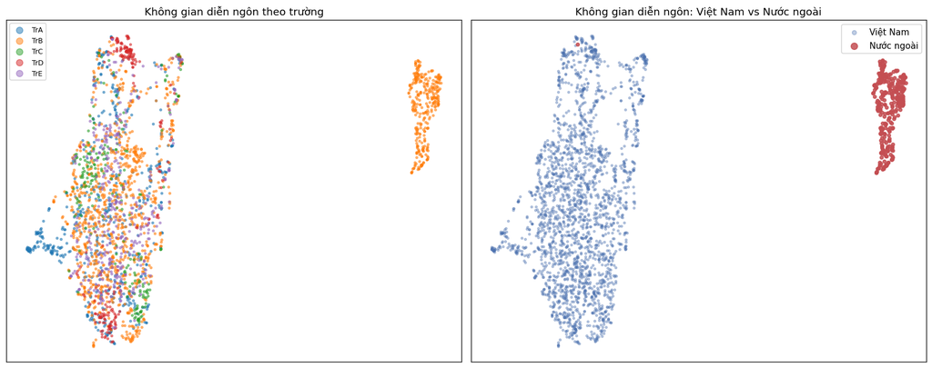

```python
# 9.3 Bản đồ 2D không gian diễn ngôn
try:
    import umap
    E2 = umap.UMAP(n_neighbors=15, n_components=2, min_dist=.1, metric='cosine',
                   random_state=RANDOM_STATE).fit_transform(E_norm)
except ImportError:
    from sklearn.decomposition import PCA
    E2 = PCA(n_components=2, random_state=RANDOM_STATE).fit_transform(E_norm)

fig, axes = plt.subplots(1, 2, figsize=(15, 6))
for s in sorted(seg.school.dropna().unique()):
    m = (seg.school == s).values
    axes[0].scatter(E2[m, 0], E2[m, 1], s=6, alpha=.5, label=s)
axes[0].legend(markerscale=3, fontsize=8); axes[0].set_title('Không gian diễn ngôn theo trường')

m = seg.is_foreign.values
axes[1].scatter(E2[~m, 0], E2[~m, 1], s=6, alpha=.35, label='Việt Nam', color='#4C72B0')
axes[1].scatter(E2[m, 0], E2[m, 1], s=14, alpha=.85, label='Nước ngoài', color='#C44E52')
axes[1].legend(markerscale=2); axes[1].set_title('Không gian diễn ngôn: Việt Nam vs Nước ngoài')
for ax in axes: ax.set_xticks([]); ax.set_yticks([])
plt.tight_layout(); plt.savefig(f'{OUT}/fig_discourse_map.png', bbox_inches='tight', dpi=140); plt.show()
```

## 10. Kiểm định độ tin cậy AI - người (Cohen's kappa)

Chuẩn mực báo cáo nghiên cứu định tính dùng AI yêu cầu **chứng minh AI không mã hóa tùy tiện**. Quy trình: lấy mẫu ngẫu nhiên các đoạn đã có mã người, để AI gán nhãn khối chủ đề bằng phương pháp *zero-shot dựa trên tương đồng ngữ nghĩa*, rồi tính kappa.

```python
# 10.1 Zero-shot gán khối chủ đề bằng tương đồng với "mô tả chủ đề"
BLOCK_DESC = {
 '00_CONTEXT': 'bối cảnh nhà trường quy mô học sinh chương trình học vị trí công tác thâm niên',
 '01_STRUCTURAL': 'tầm nhìn sứ mệnh mục tiêu chiến lược quy trình phân công kiểm định đảm bảo chất lượng',
 '02_INDIVIDUAL': 'cam kết cá nhân trách nhiệm gắn kết nỗ lực của bản thân giáo viên với chất lượng',
 '03_COLLECTIVE': 'niềm tin tập thể giá trị chung chia sẻ đồng nghiệp tin tưởng lẫn nhau',
 '04_LEADERSHIP': 'lãnh đạo ban giám hiệu tổ trưởng nêu gương phản hồi ghi nhận hỗ trợ nhân viên',
 '05_COMMUNICATION_PARTICIPATION': 'giao tiếp trao đổi thông tin họp tham gia đóng góp ý kiến hợp tác',
 '06_QCULT_IDENTIFICATION': 'nhận diện văn hóa chất lượng kiểu hình giá trị nền tảng của nhà trường',
 '07_RELATED_OUTCOMES': 'kết quả hài lòng gắn bó phát triển chuyên môn nghỉ việc động lực làm việc',
 '08_CHALLENGES': 'khó khăn thách thức rào cản áp lực quá tải thiếu nguồn lực',
 '09_CAUSES': 'nguyên nhân gốc rễ lý do vì sao dẫn đến vấn đề',
 '10_SOLUTIONS': 'giải pháp đề xuất kiến nghị cần làm gì cải thiện biện pháp',
}
desc_texts = [segment_vi(v) for v in BLOCK_DESC.values()]
desc_emb = normalize(embed_texts(desc_texts))
block_names = list(BLOCK_DESC.keys())

SAMPLE_N = min(400, len(seg))
samp = seg.sample(SAMPLE_N, random_state=RANDOM_STATE)
sim_mat = cosine_similarity(E_norm[samp.index], desc_emb)
ai_block = [block_names[i] for i in sim_mat.argmax(axis=1)]

from sklearn.metrics import cohen_kappa_score, classification_report
kappa = cohen_kappa_score(samp['sheet'].values, ai_block)
acc = float((np.array(ai_block) == samp['sheet'].values).mean())
print(f'Mẫu kiểm định: {SAMPLE_N} đoạn')
print(f"Cohen's kappa (AI vs người) = {kappa:.3f}")
print(f'Độ chính xác thô = {acc:.3f}')
print('\nDiễn giải kappa: <.20 rất thấp | .21-.40 thấp | .41-.60 trung bình | .61-.80 tốt | >.80 rất tốt')
print('Với 11 nhãn, kappa ngẫu nhiên ≈ 0. Kappa .30-.50 đã là tín hiệu AI nắm được cấu trúc chủ đề của người.')

rep = pd.DataFrame(classification_report(samp['sheet'], ai_block, output_dict=True, zero_division=0)).T
rep.round(3).to_csv(f'{OUT}/13_ai_human_kappa_report.csv', encoding='utf-8-sig')
display(rep.round(2).head(13))
json.dump({'kappa': float(kappa), 'accuracy': acc, 'n_sample': int(SAMPLE_N)},
          open(f'{OUT}/13_kappa.json', 'w', encoding='utf-8'), indent=1)
```

```
Mẫu kiểm định: 400 đoạn
Cohen's kappa (AI vs người) = 0.060
Độ chính xác thô = 0.138

Diễn giải kappa: <.20 rất thấp | .21-.40 thấp | .41-.60 trung bình | .61-.80 tốt | >.80 rất tốt
Với 11 nhãn, kappa ngẫu nhiên ≈ 0. Kappa .30-.50 đã là tín hiệu AI nắm được cấu trúc chủ đề của người.
```

|  | precision | recall | f1-score | support |
| --- | --- | --- | --- | --- |
| 00_CONTEXT | 0.58 | 0.38 | 0.46 | 37.00 |
| 01_STRUCTURAL | 0.75 | 0.05 | 0.09 | 65.00 |
| 02_INDIVIDUAL | 0.25 | 0.10 | 0.15 | 48.00 |
| 03_COLLECTIVE | 0.17 | 0.21 | 0.18 | 29.00 |
| 04_LEADERSHIP | 0.00 | 0.00 | 0.00 | 43.00 |
| 05_COMMUNICATION_PARTICIPATION | 0.00 | 0.00 | 0.00 | 37.00 |
| 06_QCULT_IDENTIFICATION | 0.09 | 0.79 | 0.16 | 33.00 |
| 07_RELATED_OUTCOMES | 0.00 | 0.00 | 0.00 | 44.00 |
| 08_CHALLENGES | 0.00 | 0.00 | 0.00 | 39.00 |
| 09_CAUSES | 0.07 | 0.11 | 0.08 | 9.00 |
| 10_SOLUTIONS | 0.00 | 0.00 | 0.00 | 16.00 |
| accuracy | 0.14 | 0.14 | 0.14 | 0.14 |
| macro avg | 0.17 | 0.15 | 0.10 | 400.00 |

## 11. Xuất ma trận lượng hóa cho phân tích hỗn hợp

Chuyển dữ liệu định tính thành các chỉ số cấp trường để **ghép với dữ liệu khảo sát định lượng** trong notebook mixed methods.

```python
# 11.1 Chỉ số định tính cấp trường
qual_school = []
for s in sorted(seg['school'].dropna().unique()):
    sub = seg[seg.school == s]
    row = {'school': s, 'n_segments': len(sub), 'n_codes': sub.code.nunique(),
           'n_sources': sub.source.nunique()}
    if 'sent_val' in seg.columns:
        row['sentiment_mean'] = round(sub.sent_val.mean(), 3)
        row['pct_negative'] = round(float((sub.sent_val < -0.2).mean() * 100), 1)
    # mật độ mã theo khối chủ đề then chốt
    for blk, lbl in [('04_LEADERSHIP','LEAD'), ('05_COMMUNICATION_PARTICIPATION','COMM'),
                     ('06_QCULT_IDENTIFICATION','QCULT'), ('08_CHALLENGES','CHAL'),
                     ('07_RELATED_OUTCOMES','OUTC')]:
        row[f'prop_{lbl}'] = round(float((sub.sheet == blk).mean() * 100), 1)
    qual_school.append(row)
QS = pd.DataFrame(qual_school)
QS.to_csv(f'{OUT}/14_qual_school_indices.csv', index=False, encoding='utf-8-sig')
display(QS)

# 11.2 Chỉ số theo nhóm (cho tích hợp với so sánh Việt/nước ngoài)
qual_group = seg.groupby('is_foreign').agg(
    n_segments=('text','size'), n_codes=('code','nunique'), n_sources=('source','nunique'),
    **({'sentiment': ('sent_val','mean')} if 'sent_val' in seg.columns else {})).round(3)
qual_group.index = ['Việt Nam', 'Nước ngoài']
qual_group.to_csv(f'{OUT}/15_qual_group_indices.csv', encoding='utf-8-sig')
display(qual_group)

seg.to_csv(f'{OUT}/16_segments_with_ai_labels.csv', index=False, encoding='utf-8-sig')
print('\nĐã xuất toàn bộ kết quả AI vào:', OUT)
```

|  | school | n_segments | n_codes | n_sources | sentiment_mean | pct_negative | prop_LEAD | prop_COMM | prop_QCULT | prop_CHAL | prop_OUTC |
| --- | --- | --- | --- | --- | --- | --- | --- | --- | --- | --- | --- |
| 0 | TrA | 566 | 256 | 5 | -0.062 | 43.6 | 12.2 | 11.8 | 9.0 | 8.3 | 8.8 |
| 1 | TrB | 1318 | 304 | 12 | 0.047 | 41.2 | 8.6 | 10.3 | 8.7 | 10.4 | 9.7 |
| 2 | TrC | 215 | 162 | 2 | -0.186 | 53.0 | 7.0 | 10.7 | 7.4 | 8.8 | 10.7 |
| 3 | TrD | 218 | 155 | 2 | -0.035 | 45.9 | 8.3 | 13.8 | 5.5 | 8.3 | 10.6 |
| 4 | TrE | 377 | 218 | 3 | 0.053 | 33.7 | 8.0 | 14.1 | 10.1 | 11.4 | 10.9 |

|  | n_segments | n_codes | n_sources | sentiment |
| --- | --- | --- | --- | --- |
| Việt Nam | 2366 | 335 | 21 | -0.127 |
| Nước ngoài | 328 | 193 | 3 | 0.916 |

```
Đã xuất toàn bộ kết quả AI vào: /content/drive/MyDrive/HuongDanSV/MsSonTDTU/DinhTinh/Phan_Tich_AI/ket_qua_ai
```

```python
# 11.3 Tổng hợp phát hiện chính (để đưa vào bài báo)
summary = {
    'corpus': corpus_stats,
    'ai_human_agreement': agree.to_dict('records'),
    'kappa': float(kappa),
    'n_network_nodes': int(G.number_of_nodes()),
    'n_network_edges': int(G.number_of_edges()),
    'top_central_codes': cent.head(10).index.tolist(),
    'convergent_codes_n': int(len(conv)),
    'divergent_codes_n': int(len(dive)),
    'discourse_cosine_vn_foreign': cos_gap,
    'discourse_permutation_p': p_val,
}
if 'sent_val' in seg.columns:
    summary['sentiment_vn'] = float(seg.loc[~seg.is_foreign, 'sent_val'].mean())
    summary['sentiment_foreign'] = float(seg.loc[seg.is_foreign, 'sent_val'].mean())
json.dump(summary, open(f'{OUT}/SUMMARY_QUAL_AI.json', 'w', encoding='utf-8'),
          ensure_ascii=False, indent=1, default=str)
print(json.dumps(summary, ensure_ascii=False, indent=1, default=str))
```

```
{
 "corpus": {
  "n_segments": 2694,
  "n_analyst_notes": 3585,
  "n_codes": 338,
  "n_sources": 24,
  "n_schools": 5,
  "n_foreign_sources": 3,
  "total_words": 563820,
  "median_words": 144.0
 },
 "ai_human_agreement": [
  {
   "Phân cụm AI": "KMeans (k=11)",
   "ARI": 0.065,
   "NMI": 0.133,
   "Purity": 0.252,
   "Silhouette": 0.3610000014305115
  },
  {
   "Phân cụm AI": "HDBSCAN (2 cụm)",
   "ARI": 0.0,
   "NMI": 0.002,
   "Purity": 0.143,
   "Silhouette": 0.8669999837875366
  }
 ],
 "kappa": 0.060252778383089955,
 "n_network_nodes": 277,
 "n_network_edges": 21288,
 "top_central_codes": [
  "VALUE-SHARED",
  "CTX-TENURE-SCHOOL",
  "TRUST-COLLEAGUE",
  "CTX-ROLE",
  "CTX-STUDENTS",
  "LEAD-SUPPORT",
  "OUT-DISSAT",
  "CTX-PROGRAM",
  "OUT-PD-EFFECT",
  "OUT-JOB-SAT"
 ],
 "convergent_codes_n": 144,
 "divergent_codes_n": 16,
 "discourse_cosine_vn_foreign": 0.7992829084396362,
 "discourse_permutation_p": 0.0,
 "sentiment_vn": -0.12707733634358628,
 "sentiment_foreign": 0.9164273099201482
}
```

## 12. Ghi chú phương pháp để viết vào bài báo

**Cách trình bày trung thực quy trình này trong bản thảo:**

**Những điều KHÔNG được viết:**

- "AI đã xác nhận kết quả mã hóa là đúng" — AI chỉ cho thấy mức độ trùng khớp.
- "Phân tích cảm xúc chứng minh giáo viên nước ngoài bất mãn" — sentiment đo giọng điệu ngôn ngữ, không đo trạng thái tâm lý.
- Bỏ qua không báo cáo kappa/ARI nếu thấp.

**Trích dẫn cần có:**

- Nguyen, D. Q., & Nguyen, A. T. (2020). PhoBERT: Pre-trained language models for Vietnamese. *Findings of EMNLP 2020*.
- Grootendorst, M. (2022). BERTopic: Neural topic modeling with a class-based TF-IDF procedure. *arXiv:2203.05794*.
- Monroe, B. L., Colaresi, M. P., & Quinn, K. M. (2008). Fightin' words. *Political Analysis*, 16(4), 372-403.
- Christou, P. A. (2023). How to use artificial intelligence in qualitative research. *Journal of Qualitative Research in Tourism*.

## 13. Đối chiếu với bốn câu hỏi nghiên cứu (RQ1–RQ4)

Hai bổ sung để nhánh định tính bám sát hệ câu hỏi nghiên cứu:

**13.1 — Ánh xạ khối chủ đề sang cấu phần của bảng tham chiếu.** Hệ mã MaxQDA được xây theo khối 00–10, còn phần định lượng theo bảng tham chiếu `BangThamChieu.pdf`. Trước đây hai hệ này chỉ tương ứng ngầm; mục này ghi thành bảng tường minh để tích hợp hỗn hợp truy vết được.

**13.2 — Phân tích *thuận lợi* (enablers), phục vụ CHNC4.** Hệ mã có `08_CHALLENGES`, `09_CAUSES`, `10_SOLUTIONS` nhưng **không có khối "thuận lợi"**, trong khi CHNC4 hỏi rõ về điều kiện thuận lợi. Thay vì mã hóa lại toàn bộ, mục này nhận diện thuận lợi từ dữ liệu sẵn có theo bốn tiêu chí: (a) thuộc khối cấu phần 01–06, (b) sentiment trung bình dương ≥ 0,05, (c) xuất hiện ở ≥ 3/5 trường, (d) có ≥ 5 đoạn trích. Kết quả đặt đối xứng với khó khăn để đọc được cán cân thuận lợi/khó khăn của từng cấu phần.

> Lưu ý diễn giải: đây là **suy luận từ sắc thái phát ngôn**, không phải mã hóa trực tiếp khái niệm "thuận lợi". Nghiên cứu sinh nên rà lại danh sách và bổ sung trích dẫn xác nhận trước khi đưa vào luận án.

```python
# 13. Đối chiếu bốn câu hỏi nghiên cứu — chạy độc lập, chỉ đọc CSV đã xuất
# (không cần PhoBERT; có thể chạy lại bất cứ lúc nào sau khi các mục trên đã chạy xong)
import subprocess, sys, os
_script = os.path.join(os.path.dirname(OUT_AI) if 'OUT_AI' in dir() else '.', 'rq_supplement.py')
if not os.path.exists(_script):
    _script = 'rq_supplement.py'
print(subprocess.run([sys.executable, _script], capture_output=True, text=True).stdout)
```

[output not shown]

```python
# 13.1 Hiển thị lại các bảng vừa sinh
import pandas as pd, os
_d = OUT_AI if 'OUT_AI' in dir() else 'ket_qua_ai'
for _f, _t in [('RQ_00_crosswalk_khoi_cau_phan.csv', 'Ánh xạ khối định tính ↔ cấu phần bảng tham chiếu'),
               ('RQ4_01_thuan_loi.csv', 'Điều kiện thuận lợi (CHNC4)'),
               ('RQ4_02_kho_khan.csv', 'Khó khăn nổi bật (CHNC4)'),
               ('RQ4_03_can_bang_thuan_loi_kho_khan.csv', 'Cán cân thuận lợi / khó khăn theo cấu phần')]:
    _p = os.path.join(_d, _f)
    if os.path.exists(_p):
        print('\n===', _t, '===')
        print(pd.read_csv(_p).head(15).to_string(index=False))
```

[output not shown]